# Clase2-ProgramaIndia

[figure not shown]

Fuente:

- https://www.kaggle.com/scratchpad/notebook4031fa4176/edit
- https://www.kaggle.com/srikarkashyap/analyzing-healthcare-data-tutorial

# Analizando datos de programas de salud (EDA)

## Introducción

NTR Vaidya Seva (o Arogya Seva) es el programa de salud insignia del gobierno de Anhra Pradesh (India), con el cual las personas de bajos ingresos de ese estado pueden obtener salud pública de forma gratuita para muchas enfermedades y dolencias importantes

## A meter código!

Comenzamos importando las librerias necesarias:

- *Pandas* para cargar datos y explorar los datos
- *Matplotlib, Seaborn* para su visualización.

```python
# Importamos las librerias
import pandas as pd
import matplotlib.pyplot as plt
%matplotlib inline
import seaborn as sns
pd.Series.__unicode__ = pd.Series.to_string
```

Vamos a leer el archivo de datos usando la función *read_csv* de Pandas. *read_csv* puede leer de manera sencilla archivos de valores separados por comas (csv).

No existen restricciones para nombrar las variables. *df*, *data* son los términos genéricos más comunes. Arrancamos con *data*.

```python
# Leemos el dataset
data = pd.read_csv('data/ntrarogyaseva.csv')
```

Explotamos los datos con la función *head()* que por defecto, muestra los primeros 5 datos.

```python
# Mostramos top5 de datos
data.head()
```

|  |  | AGE | SEX | CASTE_NAME | CATEGORY_CODE | CATEGORY_NAME | SURGERY_CODE | SURGERY | VILLAGE | MANDAL_NAME | ... | CLAIM_AMOUNT | HOSP_NAME | HOSP_TYPE | HOSP_LOCATION | HOSP_DISTRICT | SURGERY_DATE | DISCHARGE_DATE | Mortality Y / N | MORTALITY_DATE | SRC_REGISTRATION |
| --- | --- | --- | --- | --- | --- | --- | --- | --- | --- | --- | --- | --- | --- | --- | --- | --- | --- | --- | --- | --- | --- |
| 0 | 1 | 56 | Female | BC | M6 | NEPHROLOGY | M6.5 | Maintenance Hemodialysis For Crf | Lolugu | Ponduru | ... | 11000 | Rims Govt. General Hospital, Srikakulam | G | SRIKAKULAM | Srikakulam | 06/08/2013 00:00:00 | 07/09/2013 00:00:00 | NO | NaN | D |
| 1 | 2 | 37 | Male | BC | M6 | NEPHROLOGY | M6.5 | Maintenance Hemodialysis For Crf | Borivanka | Kaviti | ... | 11000 | Rims Govt. General Hospital, Srikakulam | G | SRIKAKULAM | Srikakulam | 08/08/2013 00:00:00 | 09/09/2013 00:00:00 | NO | NaN | D |
| 2 | 3 | 50 | Male | BC | M6 | NEPHROLOGY | M6.5 | Maintenance Hemodialysis For Crf | Kapasakuddi | Kaviti | ... | 11500 | Rims Govt. General Hospital, Srikakulam | G | SRIKAKULAM | Srikakulam | 15/08/2013 00:00:00 | 18/10/2013 00:00:00 | NO | NaN | D |
| 3 | 4 | 45 | Male | BC | M6 | NEPHROLOGY | M6.5 | Maintenance Hemodialysis For Crf | Telikipenta | Sarubujjili | ... | 11000 | Rims Govt. General Hospital, Srikakulam | G | SRIKAKULAM | Srikakulam | 24/08/2013 00:00:00 | 27/09/2013 00:00:00 | NO | NaN | D |
| 4 | 5 | 54 | Male | BC | M6 | NEPHROLOGY | M6.5 | Maintenance Hemodialysis For Crf | Thandemvalasa | Srikakulam | ... | 11000 | Rims Govt. General Hospital, Srikakulam | G | SRIKAKULAM | Srikakulam | 31/08/2013 00:00:00 | 02/10/2013 00:00:00 | NO | NaN | D |

5 rows × 24 columns

Ahora vamos a mostrar algunas estadisticas simples de las columnas numéricas del dataset. Utilizamos la función *describe* de los datos para obtenerlas..

```python
# Estadísticas descriptivas
# data.describe(include='all') # Incluye todas las variables
data.describe()
```

|  |  | AGE | PREAUTH_AMT | CLAIM_AMOUNT |
| --- | --- | --- | --- | --- |
| count | 479688.000000 | 479688.000000 | 479688.000000 | 479688.000000 |
| mean | 239844.500000 | 44.912264 | 30428.941698 | 27652.205861 |
| std | 138474.142301 | 18.961084 | 27441.592281 | 25951.706037 |
| min | 1.000000 | 0.000000 | 5.000000 | 2.000000 |
| 25% | 119922.750000 | 34.000000 | 12500.000000 | 12500.000000 |
| 50% | 239844.500000 | 47.000000 | 25000.000000 | 23200.000000 |
| 75% | 359766.250000 | 59.000000 | 35000.000000 | 30600.000000 |
| max | 479688.000000 | 107.000000 | 520000.000000 | 520000.000000 |

Ahora analizamos los nombres de las columnas

```python
# Muestra los nombres de las columnas en el dataset _data_
data.columns
```

```
Index(['   ', 'AGE', 'SEX', 'CASTE_NAME', 'CATEGORY_CODE', 'CATEGORY_NAME',
       'SURGERY_CODE', 'SURGERY', 'VILLAGE', 'MANDAL_NAME', 'DISTRICT_NAME',
       'PREAUTH_DATE', 'PREAUTH_AMT', 'CLAIM_DATE', 'CLAIM_AMOUNT',
       'HOSP_NAME', 'HOSP_TYPE', 'HOSP_LOCATION', 'HOSP_DISTRICT',
       'SURGERY_DATE', 'DISCHARGE_DATE', 'Mortality Y / N', 'MORTALITY_DATE',
       'SRC_REGISTRATION'],
      dtype='object')
```

```python
data.info()
```

```
<class 'pandas.core.frame.DataFrame'>
RangeIndex: 479688 entries, 0 to 479687
Data columns (total 24 columns):
 #   Column            Non-Null Count   Dtype
---  ------            --------------   -----
 0                     479688 non-null  int64
 1   AGE               479688 non-null  int64
 2   SEX               479688 non-null  object
 3   CASTE_NAME        479688 non-null  object
 4   CATEGORY_CODE     479688 non-null  object
 5   CATEGORY_NAME     479688 non-null  object
 6   SURGERY_CODE      479688 non-null  object
 7   SURGERY           479688 non-null  object
 8   VILLAGE           479688 non-null  object
 9   MANDAL_NAME       479688 non-null  object
```

[output cut: 16 more lines]

### Tamaño del dataframe

```python
data.shape
```

```
(479688, 24)
```

### Corrección de formatos

Las columnas PREAUTH_DATE, CLAIM_DATE, SURGERY_DATE, DISCHARGE_DATE y MORTALITY_DATE son cargadas como si fueran del tipo Object, cuando en realidad deberían ser levantadas como fechas

```python
# data = pd.read_csv("input/ntrarogyaseva.csv")
from datetime import datetime
```

```python
# Convertimos el campo DISCHARGE_DATE a fecha. Tira un error
data['DISCHARGE_DATE'] = pd.to_datetime(data['DISCHARGE_DATE'])
```

[output not shown]

[output cut: 33 more lines]

[output not shown]

```python
# Buscamos el error:
# Alternativa I:
data.loc[data['DISCHARGE_DATE'].str.contains('116', na=False)]
```

```python
# Alternativa II
data.loc[data['DISCHARGE_DATE']=='30/04/0116 00:00:00']
```

```python
# Reemplazamos los datos erroneos:
# Alternativa I
mappings = {'30/04/0116 00:00:00':'30/04/2016 00:00:00'}
data['DISCHARGE_DATE'] = data['DISCHARGE_DATE'].replace(mappings)

# Alternativa II
data.loc[data['DISCHARGE_DATE']=='30/04/0116 00:00:00', 'DISCHARGE_DATE'] = '30/04/2016 00:00:00'
```

```python
# Convertimos el campo DISCHARGE_DATE a fecha nuevamente
data['DISCHARGE_DATE'] = pd.to_datetime(data['DISCHARGE_DATE'])
```

```python
data['PREAUTH_DATE'] = pd.to_datetime(data['PREAUTH_DATE'])
data['CLAIM_DATE'] = pd.to_datetime(data['CLAIM_DATE'])
data['MORTALITY_DATE'] = pd.to_datetime(data['MORTALITY_DATE'])
data['SURGERY_DATE'] = pd.to_datetime(data['SURGERY_DATE'])
```

```python
# Borramos la columna que tiene el índice del CSV
data = data.drop('   ', axis = 1)
```

```python
data.to_csv('data/ntrarogyaseva_cut.csv', index = False)
```

### NAN Values

```python
data.isnull().sum()
```

```
AGE                      0
SEX                      0
CASTE_NAME               0
CATEGORY_CODE            0
CATEGORY_NAME            0
SURGERY_CODE             0
SURGERY                  0
VILLAGE                  0
MANDAL_NAME              0
DISTRICT_NAME            0
PREAUTH_DATE             0
PREAUTH_AMT              0
CLAIM_DATE               0
CLAIM_AMOUNT             0
HOSP_NAME                0
HOSP_TYPE                0
HOSP_LOCATION            0
HOSP_DISTRICT            0
SURGERY_DATE             0
DISCHARGE_DATE        4560
Mortality Y / N          0
MORTALITY_DATE      469566
SRC_REGISTRATION         0
dtype: int64
```

```python
# DISCHARGE_DATE tiene NAs porque pueden referirse a los pacientes que siguen internados o no tienen el alta
data.loc[data['DISCHARGE_DATE'].isna()]
```

|  | AGE | SEX | CASTE_NAME | CATEGORY_CODE | CATEGORY_NAME | SURGERY_CODE | SURGERY | VILLAGE | MANDAL_NAME | DISTRICT_NAME | ... | CLAIM_AMOUNT | HOSP_NAME | HOSP_TYPE | HOSP_LOCATION | HOSP_DISTRICT | SURGERY_DATE | DISCHARGE_DATE | Mortality Y / N | MORTALITY_DATE | SRC_REGISTRATION |
| --- | --- | --- | --- | --- | --- | --- | --- | --- | --- | --- | --- | --- | --- | --- | --- | --- | --- | --- | --- | --- | --- |
| 7 | 73 | Male | BC | M6 | NEPHROLOGY | M6.5 | Maintenance Hemodialysis For Crf | Bhoghapuram | Bhoghapuram | Vizianagaram | ... | 5000 | Queens Nri Hospitals | C | Visakhapatnam | Vishakhapatnam | 2014-05-05 | NaT | YES | 2014-05-23 | D |
| 10 | 52 | Male | BC | M6 | NEPHROLOGY | M6.5 | Maintenance Hemodialysis For Crf | Rajam | Butchayyapeta | Vishakhapatnam | ... | 6250 | Queens Nri Hospitals | C | Visakhapatnam | Vishakhapatnam | 2014-06-27 | NaT | YES | 2014-07-16 | P |
| 86 | 40 | Male | SC | M6 | NEPHROLOGY | M6.5 | Maintenance Hemodialysis For Crf | Dakamarri | Bheemunipatnam | Vishakhapatnam | ... | 6250 | Queens Nri Hospitals | C | Visakhapatnam | Vishakhapatnam | 2015-02-23 | NaT | YES | 2015-10-03 | D |
| 97 | 75 | Male | BC | M6 | NEPHROLOGY | M6.5 | Maintenance Hemodialysis For Crf | Ward-13 | Vijayawada | Krishna | ... | 10000 | Andhra Health Diagnostic Services LimitedGloba... | C | VIJAYAWADA | Krishna | 2015-08-04 | NaT | YES | 2015-03-05 | P |
| 122 | 58 | Female | SC | M6 | NEPHROLOGY | M6.5 | Maintenance Hemodialysis For Crf | Mudunuruu | Vuyyuru | Krishna | ... | 11250 | Andhra Health Diagnostic Services LimitedGloba... | C | VIJAYAWADA | Krishna | 2015-06-15 | NaT | YES | 2015-08-23 | D |
| ... | ... | ... | ... | ... | ... | ... | ... | ... | ... | ... | ... | ... | ... | ... | ... | ... | ... | ... | ... | ... | ... |
| 479300 | 69 | Male | OC | M6 | NEPHROLOGY | M6.5 | Maintenance Hemodialysis For Crf | Badvel (P) (U) | Badvel | YSR Kadapa | ... | 1028 | Krishna Institute of Medical Sciences Bollinen... | C | NELLORE | Nellore | 2017-10-11 | NaT | YES | 2017-11-11 | D |
| 479305 | 60 | Female | BC | M6 | NEPHROLOGY | M6.5 | Maintenance Hemodialysis For Crf | Garividi (Urban) | Garividi | Vizianagaram | ... | 5140 | Tirumala Multi Speciality Hospitals (India )Pv... | C | VIZIANAGARAM | Vizianagaram | 2017-12-11 | NaT | YES | 2017-11-26 | D |
| 479372 | 67 | Female | BC | M5 | CARDIOLOGY | M5.1.2 | Management Of Acute MI With Angiogram | Ambapuram | Nellore | Nellore | ... | 10000 | Krishna Institute of Medical Sciences Bollinen... | C | NELLORE | Nellore | 2017-10-11 | NaT | YES | 2017-11-11 | D |
| 479403 | 0 | Male(Child) | Minorities | M4 | PEDIATRICS | M4.1.14 | Medical Management of Term Baby With Severe Pe... | Guntur (U) | Guntur | Guntur | ... | 40000 | MOTHER THERESA MULTI SPECIALITY | C | NARSARAOPET | Guntur | 2017-11-11 | NaT | YES | 2017-11-17 | D |
| 479404 | 46 | Female | BC | M1 | CRITICAL CARE | M1.4 | Medical Management of ARDS | Poolathota | Doravarisatram | Nellore | ... | 10000 | Krishna Institute of Medical Sciences Bollinen... | C | NELLORE | Nellore | 2017-11-11 | NaT | YES | 2017-11-11 | D |

4560 rows × 23 columns

```python
# Podemos chequear si hay pacientes con DISCHARGE_DATE NA y que hallan fallecido
data.loc[(data['Mortality Y / N']=='YES') & (data['DISCHARGE_DATE'].isna())]
```

|  | AGE | SEX | CASTE_NAME | CATEGORY_CODE | CATEGORY_NAME | SURGERY_CODE | SURGERY | VILLAGE | MANDAL_NAME | DISTRICT_NAME | ... | CLAIM_AMOUNT | HOSP_NAME | HOSP_TYPE | HOSP_LOCATION | HOSP_DISTRICT | SURGERY_DATE | DISCHARGE_DATE | Mortality Y / N | MORTALITY_DATE | SRC_REGISTRATION |
| --- | --- | --- | --- | --- | --- | --- | --- | --- | --- | --- | --- | --- | --- | --- | --- | --- | --- | --- | --- | --- | --- |
| 7 | 73 | Male | BC | M6 | NEPHROLOGY | M6.5 | Maintenance Hemodialysis For Crf | Bhoghapuram | Bhoghapuram | Vizianagaram | ... | 5000 | Queens Nri Hospitals | C | Visakhapatnam | Vishakhapatnam | 2014-05-05 | NaT | YES | 2014-05-23 | D |
| 10 | 52 | Male | BC | M6 | NEPHROLOGY | M6.5 | Maintenance Hemodialysis For Crf | Rajam | Butchayyapeta | Vishakhapatnam | ... | 6250 | Queens Nri Hospitals | C | Visakhapatnam | Vishakhapatnam | 2014-06-27 | NaT | YES | 2014-07-16 | P |
| 86 | 40 | Male | SC | M6 | NEPHROLOGY | M6.5 | Maintenance Hemodialysis For Crf | Dakamarri | Bheemunipatnam | Vishakhapatnam | ... | 6250 | Queens Nri Hospitals | C | Visakhapatnam | Vishakhapatnam | 2015-02-23 | NaT | YES | 2015-10-03 | D |
| 97 | 75 | Male | BC | M6 | NEPHROLOGY | M6.5 | Maintenance Hemodialysis For Crf | Ward-13 | Vijayawada | Krishna | ... | 10000 | Andhra Health Diagnostic Services LimitedGloba... | C | VIJAYAWADA | Krishna | 2015-08-04 | NaT | YES | 2015-03-05 | P |
| 122 | 58 | Female | SC | M6 | NEPHROLOGY | M6.5 | Maintenance Hemodialysis For Crf | Mudunuruu | Vuyyuru | Krishna | ... | 11250 | Andhra Health Diagnostic Services LimitedGloba... | C | VIJAYAWADA | Krishna | 2015-06-15 | NaT | YES | 2015-08-23 | D |
| ... | ... | ... | ... | ... | ... | ... | ... | ... | ... | ... | ... | ... | ... | ... | ... | ... | ... | ... | ... | ... | ... |
| 479300 | 69 | Male | OC | M6 | NEPHROLOGY | M6.5 | Maintenance Hemodialysis For Crf | Badvel (P) (U) | Badvel | YSR Kadapa | ... | 1028 | Krishna Institute of Medical Sciences Bollinen... | C | NELLORE | Nellore | 2017-10-11 | NaT | YES | 2017-11-11 | D |
| 479305 | 60 | Female | BC | M6 | NEPHROLOGY | M6.5 | Maintenance Hemodialysis For Crf | Garividi (Urban) | Garividi | Vizianagaram | ... | 5140 | Tirumala Multi Speciality Hospitals (India )Pv... | C | VIZIANAGARAM | Vizianagaram | 2017-12-11 | NaT | YES | 2017-11-26 | D |
| 479372 | 67 | Female | BC | M5 | CARDIOLOGY | M5.1.2 | Management Of Acute MI With Angiogram | Ambapuram | Nellore | Nellore | ... | 10000 | Krishna Institute of Medical Sciences Bollinen... | C | NELLORE | Nellore | 2017-10-11 | NaT | YES | 2017-11-11 | D |
| 479403 | 0 | Male(Child) | Minorities | M4 | PEDIATRICS | M4.1.14 | Medical Management of Term Baby With Severe Pe... | Guntur (U) | Guntur | Guntur | ... | 40000 | MOTHER THERESA MULTI SPECIALITY | C | NARSARAOPET | Guntur | 2017-11-11 | NaT | YES | 2017-11-17 | D |
| 479404 | 46 | Female | BC | M1 | CRITICAL CARE | M1.4 | Medical Management of ARDS | Poolathota | Doravarisatram | Nellore | ... | 10000 | Krishna Institute of Medical Sciences Bollinen... | C | NELLORE | Nellore | 2017-11-11 | NaT | YES | 2017-11-11 | D |

4559 rows × 23 columns

```python
# Los MORTALITY_DATE en blanco, es porque no falleció o por error en la base
data.loc[(data['Mortality Y / N']=='NO') & (data['MORTALITY_DATE'].isna())]
```

|  | AGE | SEX | CASTE_NAME | CATEGORY_CODE | CATEGORY_NAME | SURGERY_CODE | SURGERY | VILLAGE | MANDAL_NAME | DISTRICT_NAME | ... | CLAIM_AMOUNT | HOSP_NAME | HOSP_TYPE | HOSP_LOCATION | HOSP_DISTRICT | SURGERY_DATE | DISCHARGE_DATE | Mortality Y / N | MORTALITY_DATE | SRC_REGISTRATION |
| --- | --- | --- | --- | --- | --- | --- | --- | --- | --- | --- | --- | --- | --- | --- | --- | --- | --- | --- | --- | --- | --- |
| 0 | 56 | Female | BC | M6 | NEPHROLOGY | M6.5 | Maintenance Hemodialysis For Crf | Lolugu | Ponduru | Srikakulam | ... | 11000 | Rims Govt. General Hospital, Srikakulam | G | SRIKAKULAM | Srikakulam | 2013-06-08 | 2013-07-09 | NO | NaT | D |
| 1 | 37 | Male | BC | M6 | NEPHROLOGY | M6.5 | Maintenance Hemodialysis For Crf | Borivanka | Kaviti | Srikakulam | ... | 11000 | Rims Govt. General Hospital, Srikakulam | G | SRIKAKULAM | Srikakulam | 2013-08-08 | 2013-09-09 | NO | NaT | D |
| 2 | 50 | Male | BC | M6 | NEPHROLOGY | M6.5 | Maintenance Hemodialysis For Crf | Kapasakuddi | Kaviti | Srikakulam | ... | 11500 | Rims Govt. General Hospital, Srikakulam | G | SRIKAKULAM | Srikakulam | 2013-08-15 | 2013-10-18 | NO | NaT | D |
| 3 | 45 | Male | BC | M6 | NEPHROLOGY | M6.5 | Maintenance Hemodialysis For Crf | Telikipenta | Sarubujjili | Srikakulam | ... | 11000 | Rims Govt. General Hospital, Srikakulam | G | SRIKAKULAM | Srikakulam | 2013-08-24 | 2013-09-27 | NO | NaT | D |
| 4 | 54 | Male | BC | M6 | NEPHROLOGY | M6.5 | Maintenance Hemodialysis For Crf | Thandemvalasa | Srikakulam | Srikakulam | ... | 11000 | Rims Govt. General Hospital, Srikakulam | G | SRIKAKULAM | Srikakulam | 2013-08-31 | 2013-02-10 | NO | NaT | D |
| ... | ... | ... | ... | ... | ... | ... | ... | ... | ... | ... | ... | ... | ... | ... | ... | ... | ... | ... | ... | ... | ... |
| 479683 | 22 | Female | BC | S4 | GYNAECOLOGY AND OBSTETRICS SURGERY | S4.2.2 | Laparoscopic Cystectomy | Kalayakagollu | Butchireddipalem | Nellore | ... | 24910 | Krishna Institute of Medical Sciences Bollinen... | C | NELLORE | Nellore | 2017-11-15 | 2017-11-19 | NO | NaT | D |
| 479684 | 60 | Male | BC | S12 | MEDICAL ONCOLOGY | S12.16.2.2 | Chemotherapy for Non Hodgkin Lymphoma with R ... | Rajupalem | Kothapatnam | Prakasam | ... | 45910 | Manipal Health Enterprises PVT LTD | C | GUNTUR | Guntur | 2017-11-17 | 2017-11-18 | NO | NaT | D |
| 479685 | 38 | Male | OC | S15 | POLY TRAUMA | S15.1.1 | Surgical Correction Of Longbone Fracture | Yeturu | Chejerla | Nellore | ... | 30000 | Krishna Institute of Medical Sciences Bollinen... | C | NELLORE | Nellore | 2017-11-16 | 2017-11-18 | NO | NaT | D |
| 479686 | 59 | Male | OC | S3 | OPHTHALMOLOGY SURGERY | S3.3.1 | Vitrectomy | Ganapavaram | Ganapavaram | West Godavari | ... | 23020 | Sankar Eye Hospital | C | GUNTUR | Guntur | 2017-11-16 | 2017-11-18 | NO | NaT | D |
| 479687 | 63 | Male | OC | S3 | OPHTHALMOLOGY SURGERY | S3.3.1 | Vitrectomy | Savarigudem | Gannavaram | Krishna | ... | 23020 | Sankar Eye Hospital | C | GUNTUR | Guntur | 2017-11-16 | 2017-11-18 | NO | NaT | D |

469566 rows × 23 columns

## Analizando un poco mas profundo...

### Cual es la distribución de la variable SEX?

*value_counts()* es una función de Pandas que puede ser usada para obtener la distribución de los datos, en la columna que se especifique.

```python
# Cantidad de cada valor en la columna SEX
data['SEX'].value_counts()
```

```
Male             260718
Female           178947
Male(Child)       25068
Female(Child)     14925
FEMALE               21
MALE                  9
Name: SEX, dtype: int64
```

*CUIDADO*: Existe valores que están ingresados de forma diferente, que refieren al mismo valor. *Male* and *MALE* no representan valores diferentes!

Es posible hacer un *replace* de los valores mal ingresados para normalizar la variable. (Ademas de reemplazar Male (Child) -> Boy and Female (Child) -> Girl por conveniencia)

```python
# Mapeamos para normalizar
mappings = {'MALE' : 'Male', 'FEMALE' : 'Female', 'Male(Child)' : 'Boy', 'Female(Child)' : 'Girl'}
```

```python
# Reemplazamos los valores utilizando el mapping arriba definido
data['SEX'] = data['SEX'].replace(mappings)
data['SEX'].value_counts()
```

```
Male      260727
Female    178968
Boy        25068
Girl       14925
Name: SEX, dtype: int64
```

La visualización de esta información se puede hacer de manera sencilla utilizando la función gráfica que incluye Pandas.

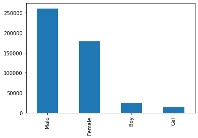

```python
# Value count de Sex de forma gráfica
data['SEX'].value_counts().plot.bar()
```

### Cual es la distribución de la variable AGE?

Media, mediana y moda:

```python
# print the mean, median and mode of the age distribution
print("Mean: {}".format(data['AGE'].mean()))
print("Median: {}".format(data['AGE'].median()))
print("Mode: {}".format(data['AGE'].mode()))
```

```
Mean: 44.91226380480646
Median: 47.0
Mode: 0    0
Name: AGE, dtype: int64
```

Top 10 de las edades mas repetidas.

```python
# top 10 age
data['AGE'].value_counts().head(10)
```

```
0     17513
50    16191
55    15184
45    15052
60    13732
46    12858
56    12590
51    12470
40    11962
65    11878
Name: AGE, dtype: int64
```

Box plots are commonly used for visualizing a distribution when bar plots or scatter plots are too overwhelming to understand.

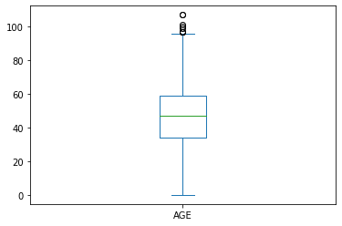

```python
# boxplot para AGE
data['AGE'].plot.box()
```

En el grafico de arriba, la caja representa el **[Rango Intercuatilico (IQR, en inglés)](https://es.wikipedia.org/wiki/Rango_intercuart%C3%ADlico)** de los datos.

El IQR representa la región donde cae el 50% de los datos. Por ejemplo del 25% al 75% del dataframe. Todo dato que cae fuera de 1.5 veces el IQR es considerado, en general, una anomalía (OJO, NO SIEMPRE, DEPENDE DEL CONOCIMIENTO DE LOS DATOS POR PARTE DEL ANALISTA)

Los círculos se considerarían *outliers*

La librería *Seaborn* ofrece visualizaciones mejores, de forma sencilla.

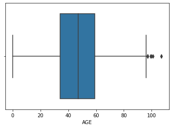

```python
# sns.boxplot(data['AGE']) # Devuelve un warning, que se solucina definiendo x e y.
sns.boxplot(x=data['AGE']); # El ; evita la impresión de texto previo al gráfico.
```

### Preguntando y respondiendo con los datos

Una vez que hayamos realizado una pequeña exploración en los datos, ahora avancemos a realizarnos algunas preguntas para entender mejor el dataframe.

**Qué debería hacer si sólo quiero analizar los registros que pertenecen al distrito de Krishna?**

Deberí selecciononar un subconjunto de datos pertenencientes a Krishna. Pandas lo hace en dos sencillos pasos:

```
1. Condición que se debe satisfacer: data['DISTRICT_NAME']=='Krishna'
2. Insertamos la condición en el dataframe: [data['DISTRICT_NAME']=='Krishna']
```

```python
# subset de datos que pertenecen al distrito de Krishna
data[data['DISTRICT_NAME']=='Krishna'].head()
```

|  | AGE | SEX | CASTE_NAME | CATEGORY_CODE | CATEGORY_NAME | SURGERY_CODE | SURGERY | VILLAGE | MANDAL_NAME | DISTRICT_NAME | ... | CLAIM_AMOUNT | HOSP_NAME | HOSP_TYPE | HOSP_LOCATION | HOSP_DISTRICT | SURGERY_DATE | DISCHARGE_DATE | Mortality Y / N | MORTALITY_DATE | SRC_REGISTRATION |
| --- | --- | --- | --- | --- | --- | --- | --- | --- | --- | --- | --- | --- | --- | --- | --- | --- | --- | --- | --- | --- | --- |
| 30 | 42 | Female | OC | S12 | MEDICAL ONCOLOGY | S12.26.1 | Chemotherapy for Acute Myeloid Leukemia with I... | Ward-1 | Vijayawada | Krishna | ... | 60000 | Nims Hospitals | G | HYDERABAD | Hyderabad | 2014-06-08 | 2014-01-09 | NO | NaT | D |
| 56 | 52 | Male | BC | M5 | CARDIOLOGY | M5.1.2 | Management Of Acute MI With Angiogram | Ward-26 | Vijayawada | Krishna | ... | 25000 | OZONE HOSPITALS | C | HYDERABAD | Ranga Reddy | 2014-10-28 | 2014-06-11 | NO | NaT | D |
| 58 | 17 | Female | SC | S7 | CARDIAC AND CARDIOTHORACIC SURGERY | S7.2.10.1 | Mitral Valve Replacement (With Valve) | Atapaka | Kaikalur | Krishna | ... | 135000 | Karumuri Hospital | C | GUNTUR | Guntur | 2014-04-11 | 2014-12-11 | NO | NaT | D |
| 97 | 75 | Male | BC | M6 | NEPHROLOGY | M6.5 | Maintenance Hemodialysis For Crf | Ward-13 | Vijayawada | Krishna | ... | 10000 | Andhra Health Diagnostic Services LimitedGloba... | C | VIJAYAWADA | Krishna | 2015-08-04 | NaT | YES | 2015-03-05 | P |
| 111 | 65 | Male | OC | M7 | NEUROLOGY | M7.4 | Medical Management of Ischemic Strokes | Chilakalapudi (R) | Machilipatnam | Krishna | ... | 10000 | Rims General Hospital | G | KADAPA | YSR Kadapa | 2015-05-28 | 2015-01-06 | NO | NaT | D |

5 rows × 23 columns

**Enfermedad/intervención con mayor prevalencia, por distrito**

Se puede obtener iterando a través de todos los distritos, y seleccionando el subset de datos para cada uno de ellos.

```python
# Iteración
for i in data['DISTRICT_NAME'].unique():
    print("Distrito: {}\nEnfermedad/intervención y Count: {}".format(i,data[data['DISTRICT_NAME']==i]['SURGERY'].value_counts().head(1)))
```

```
Distrito: Srikakulam
Enfermedad/intervención y Count: Maintenance Hemodialysis For Crf    3970
Name: SURGERY, dtype: int64
Distrito: Kurnool
Enfermedad/intervención y Count: Surgical Correction Of Longbone Fracture    2943
Name: SURGERY, dtype: int64
Distrito: Vizianagaram
Enfermedad/intervención y Count: Surgical Correction Of Longbone Fracture    2754
Name: SURGERY, dtype: int64
Distrito: Guntur
Enfermedad/intervención y Count: Surgical Correction Of Longbone Fracture    5259
Name: SURGERY, dtype: int64
Distrito: Vishakhapatnam
Enfermedad/intervención y Count: Maintenance Hemodialysis For Crf    5270
Name: SURGERY, dtype: int64
Distrito: West Godavari
Enfermedad/intervención y Count: Maintenance Hemodialysis For Crf    5478
Name: SURGERY, dtype: int64
Distrito: Krishna
Enfermedad/intervención y Count: Maintenance Hemodialysis For Crf    6026
Name: SURGERY, dtype: int64
Distrito: East Godavari
Enfermedad/intervención y Count: Surgical Correction Of Longbone Fracture    6998
Name: SURGERY, dtype: int64
Distrito: Prakasam
Enfermedad/intervención y Count: Maintenance Hemodialysis For Crf    6215
Name: SURGERY, dtype: int64
Distrito: Nellore
Enfermedad/intervención y Count: Maintenance Hemodialysis For Crf    10824
Name: SURGERY, dtype: int64
Distrito: YSR Kadapa
Enfermedad/intervención y Count: Surgical Correction Of Longbone Fracture    4532
Name: SURGERY, dtype: int64
Distrito: Chittoor
Enfermedad/intervención y Count: Maintenance Hemodialysis For Crf    5221
Name: SURGERY, dtype: int64
Distrito: Anantapur
Enfermedad/intervención y Count: Surgical Correction Of Longbone Fracture    5265
Name: SURGERY, dtype: int64
```

**Promedio de claim amount, por distrito**

```python
# Average claim amount for surgery by district
for i in data['DISTRICT_NAME'].unique():
    print("Distrito: {}\nMedia Claim Amount: ₹{}".format(i,data[data['DISTRICT_NAME']==i]['CLAIM_AMOUNT'].mean()))
```

```
Distrito: Srikakulam
Media Claim Amount: ₹25593.712618634367
Distrito: Kurnool
Media Claim Amount: ₹28598.91853309593
Distrito: Vizianagaram
Media Claim Amount: ₹25097.78006899492
Distrito: Guntur
Media Claim Amount: ₹31048.73950729927
Distrito: Vishakhapatnam
Media Claim Amount: ₹25977.94638304871
Distrito: West Godavari
Media Claim Amount: ₹27936.70608610806
Distrito: Krishna
Media Claim Amount: ₹31015.383233247547
Distrito: East Godavari
Media Claim Amount: ₹26166.136719737173
Distrito: Prakasam
Media Claim Amount: ₹28655.81036215859
Distrito: Nellore
Media Claim Amount: ₹26105.122376744654
Distrito: YSR Kadapa
Media Claim Amount: ₹27945.216899192998
Distrito: Chittoor
Media Claim Amount: ₹25708.102690948628
Distrito: Anantapur
Media Claim Amount: ₹27664.166978581827
```

El desvio estandar no parece ser demasiado alto. El distrito de Guntur es el de valor mas alto con ₹31048 mientras Vizianagaram ocupa el último lugar con ₹25097

**Estadísticas por categoria de operación**

Vamos a utilizar el *groupby* de Pandas para construir estadísticas, agrupando los datos por la categoría de operación. El *groupby* trabaja de forma similar al comando de *SQL* del mismo nombre

```python
# group by surgery para obtener estadísticas
data.groupby('CATEGORY_NAME').mean()
```

| CATEGORY_NAME | AGE | PREAUTH_AMT | CLAIM_AMOUNT |
| --- | --- | --- | --- |
| CARDIAC AND CARDIOTHORACIC SURGERY | 51.764553 | 87052.165471 | 82487.123074 |
| CARDIOLOGY | 54.652048 | 33215.140211 | 26731.893660 |
| COCHLEAR IMPLANT SURGERY | 1.581081 | 520000.000000 | 516486.486486 |
| CRITICAL CARE | 51.014649 | 69927.226196 | 50185.150797 |
| DERMATOLOGY | 46.573171 | 28003.012195 | 21728.353659 |
| ENDOCRINOLOGY | 45.066667 | 18981.376471 | 14875.437255 |
| ENT SURGERY | 32.521940 | 15691.907198 | 14938.095612 |
| GASTROENTEROLOGY | 41.662383 | 37085.464601 | 23798.118922 |
| GENERAL MEDICINE | 35.330161 | 30347.573939 | 21840.991215 |
| GENERAL SURGERY | 44.979473 | 29818.585421 | 28142.764203 |
| GENITO URINARY SURGERIES | 43.718295 | 29426.211532 | 28709.646344 |
| GYNAECOLOGY AND OBSTETRICS SURGERY | 41.442323 | 27614.600699 | 23180.202474 |
| INFECTIOUS DISEASES | 35.800000 | 27970.000000 | 24336.000000 |
| MEDICAL ONCOLOGY | 48.545298 | 7234.080290 | 6819.998475 |
| NEPHROLOGY | 48.011808 | 14309.566173 | 13524.963628 |
| NEUROLOGY | 56.160018 | 24547.013248 | 19810.427139 |
| NEUROSURGERY | 43.187689 | 53718.705139 | 49993.359806 |
| OPHTHALMOLOGY SURGERY | 49.846924 | 16474.566599 | 15848.563286 |
| ORTHOPEDIC SURGERY AND PROCEDURES | 36.967490 | 27358.743536 | 23291.952598 |
| PEDIATRIC SURGERIES | 3.504840 | 34134.385044 | 32061.504598 |
| PEDIATRICS | 1.413553 | 29797.617781 | 24837.604014 |
| PLASTIC SURGERY | 27.419738 | 61115.505351 | 37437.164090 |
| POLY TRAUMA | 46.256150 | 32501.263044 | 28247.750837 |
| PROSTHESES | 48.500000 | 1200.000000 | 1200.000000 |
| PULMONOLOGY | 51.937149 | 32743.249244 | 25631.090065 |
| RADIATION ONCOLOGY | 51.835382 | 33656.716935 | 31808.693718 |
| RHEUMATOLOGY | 29.392857 | 28897.321429 | 20852.372449 |
| SURGICAL GASTRO ENTEROLOGY | 44.645103 | 64127.925427 | 59249.639712 |
| SURGICAL ONCOLOGY | 50.940826 | 45243.913335 | 42502.467151 |

**Operación mas común por grupo de edad**

Para encontrar la operación mas común por grupo de edad, vamos a redondear las edades al valor múltiplo de 10 mas cercano.

Hacemos una copia del dataframe para no *ensuciar* el dataframe original.

```python
dataround = data.copy()
```

Utilizamos la función *round* de Pandas para redonder el valor de la edad. *-1* indica que redondeamos hasta1 dígito a la izquierda del valor decimal.

```python
# round a la edad en 0 o 1
dataround['AGE'] = dataround['AGE'].round(-1)
```

Visualizamos los grupos de edad utilizando la función *Seaborn countplot*

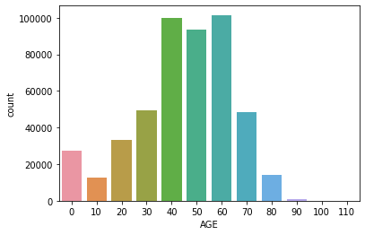

```python
# frequency plot
sns.countplot(x=dataround['AGE'])
```

```python
for i in sorted(dataround['AGE'].unique()):
    print("Age Group: {}\nMost Common Surgery and Count: {}".format(i,data[data['AGE']==i]['CATEGORY_NAME'].value_counts().head(1)))
```

```
Age Group: 0
Most Common Surgery and Count: PEDIATRICS    15096
Name: CATEGORY_NAME, dtype: int64
Age Group: 10
Most Common Surgery and Count: POLY TRAUMA    390
Name: CATEGORY_NAME, dtype: int64
Age Group: 20
Most Common Surgery and Count: POLY TRAUMA    729
Name: CATEGORY_NAME, dtype: int64
Age Group: 30
Most Common Surgery and Count: POLY TRAUMA    1125
Name: CATEGORY_NAME, dtype: int64
Age Group: 40
Most Common Surgery and Count: MEDICAL ONCOLOGY    2425
Name: CATEGORY_NAME, dtype: int64
Age Group: 50
Most Common Surgery and Count: MEDICAL ONCOLOGY    3171
Name: CATEGORY_NAME, dtype: int64
Age Group: 60
Most Common Surgery and Count: MEDICAL ONCOLOGY    2447
Name: CATEGORY_NAME, dtype: int64
Age Group: 70
Most Common Surgery and Count: POLY TRAUMA    1845
Name: CATEGORY_NAME, dtype: int64
Age Group: 80
Most Common Surgery and Count: POLY TRAUMA    584
Name: CATEGORY_NAME, dtype: int64
Age Group: 90
Most Common Surgery and Count: POLY TRAUMA    67
Name: CATEGORY_NAME, dtype: int64
Age Group: 100
Most Common Surgery and Count: POLY TRAUMA    1
Name: CATEGORY_NAME, dtype: int64
Age Group: 110
Most Common Surgery and Count: Series([], Name: CATEGORY_NAME, dtype: int64)
```

### Anomalías

Fuente: https://towardsdatascience.com/5-ways-to-detect-outliers-that-every-data-scientist-should-know-python-code-70a54335a623

#### Con función

```python
import numpy as np
import matplotlib.pyplot as plt

np.random.seed(seed=1)

# Creamos set random de datos
data = np.random.randn(50000) * 20 + 20
```

[output not shown]

[output not shown]

[output cut: 87 more lines]

[output not shown]

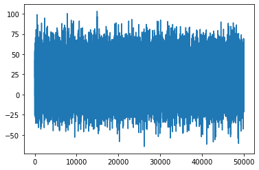

```python
# Función para detectar outliers en un dataset unidimensional
def find_anomalies(data):
    #Definimos lista para acumular anomalias
    anomalies = []
    # Definimos limites +- 3 desvios
    random_data_std = np.std(data)
    random_data_mean = np.mean(data)
    anomaly_cut_off = random_data_std * 3
    print(random_data_std)
    print(random_data_mean)
    lower_limit  = random_data_mean - anomaly_cut_off
    upper_limit = random_data_mean + anomaly_cut_off
#     plt.plot (data)
#     plt.fill_between(range(6),lower_limit,upper_limit,alpha=.1)
    sns.lineplot(data=data)
    # Generamos ouliers
    for outlier in data:
        if outlier > upper_limit or outlier < lower_limit:
            anomalies.append(outlier)
    return anomalies

find_anomalies(data)
```

### Graficamente (más sencillo)

#### Intervalos de confianza

```python
# Leemos el dataset
data = pd.read_csv('data/ntrarogyaseva_cut.csv')
```

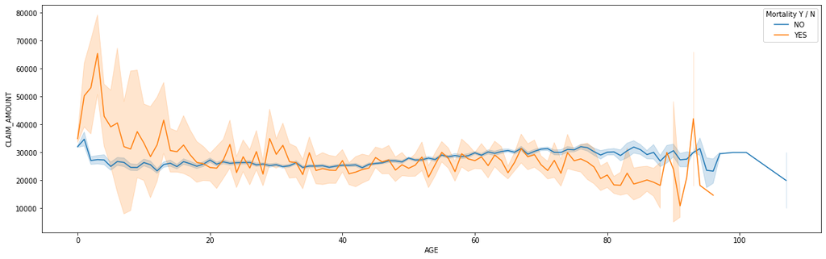

```python
plt.figure(figsize=(20, 6))
sns.lineplot(data=data, x="AGE", y="CLAIM_AMOUNT", ci=95, hue="Mortality Y / N")
```

```python
# Reducimos el DF para trabajar con mayor velocidad
data_graph = data.loc[data['SURGERY_DATE']>'31/03/2016 00:00:00']
data_graph = data_graph.copy()
data_graph.shape
```

```
(0, 23)
```

```python
data_graph.columns
```

```
Index(['AGE', 'SEX', 'CASTE_NAME', 'CATEGORY_CODE', 'CATEGORY_NAME',
       'SURGERY_CODE', 'SURGERY', 'VILLAGE', 'MANDAL_NAME', 'DISTRICT_NAME',
       'PREAUTH_DATE', 'PREAUTH_AMT', 'CLAIM_DATE', 'CLAIM_AMOUNT',
       'HOSP_NAME', 'HOSP_TYPE', 'HOSP_LOCATION', 'HOSP_DISTRICT',
       'SURGERY_DATE', 'DISCHARGE_DATE', 'Mortality Y / N', 'MORTALITY_DATE',
       'SRC_REGISTRATION'],
      dtype='object')
```

[figure not shown]

```python
plt.figure(figsize=(20, 6))
ax = sns.lineplot(data=data_graph, x="SURGERY_DATE", y="CLAIM_AMOUNT")
plt.xticks(rotation=45); # el ; oculta el texto previo al gráfico. El mismo resultado se logra con plt.show()
```

```python
data_graph.sort_values(by='SURGERY_DATE', ascending=False)
data_graph['CLAIM_AMOUNT_min'] = data_graph['CLAIM_AMOUNT'].rolling(5).mean() - 3*data_graph['CLAIM_AMOUNT'].rolling(5).std()
data_graph['CLAIM_AMOUNT_max'] = data_graph['CLAIM_AMOUNT'].rolling(5).mean() + 3*data_graph['CLAIM_AMOUNT'].rolling(5).std()
data_graph['CLAIM_AMOUNT_RM'] = data_graph['CLAIM_AMOUNT'].rolling(5).mean()

data_graph['CLAIM_AMOUNT_min'] = data_graph['CLAIM_AMOUNT'] - 3*data_graph['CLAIM_AMOUNT']
data_graph['CLAIM_AMOUNT_max'] = data_graph['CLAIM_AMOUNT'] + 3*data_graph['CLAIM_AMOUNT']
# data_graph['CLAIM_AMOUNT_RM'] = data_graph['CLAIM_AMOUNT'].rolling(5).mean()
```

```python
# data_graph['CLAIM_AMOUNT_RM_OK'] =
data_graph.loc[data_graph['SURGERY_DATE']=='2017-11-01']
```

|  | AGE | SEX | CASTE_NAME | CATEGORY_CODE | CATEGORY_NAME | SURGERY_CODE | SURGERY | VILLAGE | MANDAL_NAME | DISTRICT_NAME | ... | HOSP_LOCATION | HOSP_DISTRICT | SURGERY_DATE | DISCHARGE_DATE | Mortality Y / N | MORTALITY_DATE | SRC_REGISTRATION | CLAIM_AMOUNT_min | CLAIM_AMOUNT_max | CLAIM_AMOUNT_RM |
| --- | --- | --- | --- | --- | --- | --- | --- | --- | --- | --- | --- | --- | --- | --- | --- | --- | --- | --- | --- | --- | --- |

0 rows × 26 columns

```python
data_graph.tail()
```

|  | AGE | SEX | CASTE_NAME | CATEGORY_CODE | CATEGORY_NAME | SURGERY_CODE | SURGERY | VILLAGE | MANDAL_NAME | DISTRICT_NAME | ... | HOSP_LOCATION | HOSP_DISTRICT | SURGERY_DATE | DISCHARGE_DATE | Mortality Y / N | MORTALITY_DATE | SRC_REGISTRATION | CLAIM_AMOUNT_min | CLAIM_AMOUNT_max | CLAIM_AMOUNT_RM |
| --- | --- | --- | --- | --- | --- | --- | --- | --- | --- | --- | --- | --- | --- | --- | --- | --- | --- | --- | --- | --- | --- |

0 rows × 26 columns

```python
fig, ax = plt.subplots(figsize=(20, 6))

sns.lineplot(x='SURGERY_DATE',
             y='CLAIM_AMOUNT_max',
             data=data_graph,
             ci=False)

sns.lineplot(x='SURGERY_DATE',
             y='CLAIM_AMOUNT_min',
             data=data_graph,
             color='y',
             ci=False)

sns.lineplot(x='SURGERY_DATE',
             y='CLAIM_AMOUNT',
             data=data_graph,
             color='g')

sns.scatterplot(x='SURGERY_DATE',
             y='CLAIM_AMOUNT',
             data=data_graph,
             color='g')

# ax.axes.set_title("Date and Claim Amount",fontsize=20)
# ax.set_xlabel("Date",fontsize=15)
# ax.set_ylabel("Claim Amount",fontsize=15)
# ax.tick_params(labelsize=5)
# plt.xticks(rotation=45)

plt.show()
```

[output not shown]

```python
# Agrupamos los datos por fecha, con el promedio del CLAIM_AMOUNT
graph = data_graph.groupby(['SURGERY_DATE']).agg({'CLAIM_AMOUNT': 'mean'}).reset_index()

# Calculamos el la media movil para el CLAIM_AMOUNT y -+ 3 desvíos
graph.sort_values(by='SURGERY_DATE', ascending=False)
graph['CLAIM_AMOUNT_min'] = graph['CLAIM_AMOUNT'].rolling(5).mean() - 3*graph['CLAIM_AMOUNT'].rolling(5).std()
graph['CLAIM_AMOUNT_max'] = graph['CLAIM_AMOUNT'].rolling(5).mean() + 3*graph['CLAIM_AMOUNT'].rolling(5).std()
graph['CLAIM_AMOUNT_RM'] = graph['CLAIM_AMOUNT'].rolling(5).mean()

fig, ax = plt.subplots(figsize=(20, 6))

sns.lineplot(x='SURGERY_DATE',
             y='CLAIM_AMOUNT_max',
             data=graph,
             ci=False)

sns.lineplot(x='SURGERY_DATE',
             y='CLAIM_AMOUNT_min',
             data=graph,
             color='y',
             ci=False)

sns.lineplot(x='SURGERY_DATE',
             y='CLAIM_AMOUNT_RM',
             data=graph,
             color='g')

sns.scatterplot(x='SURGERY_DATE',
             y='CLAIM_AMOUNT',
             data=data_graph,
             color='g');
```

[output not shown]

```python
fig, ax = plt.subplots(figsize=(20, 6))

sns.boxplot(x=data_graph['DISTRICT_NAME'], y=data_graph['CLAIM_AMOUNT']);
```

[output not shown]

#### Eliminar outliers

- Computamos el Z-score para la columna seleccionada, relativo a la media y al STD de esa columna
- Tomamos el valor absoluto del Z-score.

Si queremos calcular para todas las variables

- df[(np.abs(stats.zscore(df)) < 3).all(axis=1)]

```python
from scipy import stats
import numpy as np
# graph_graph = data_graph.groupby(['SURGERY_DATE']).agg({'CLAIM_AMOUNT': 'mean'}).reset_index()

data_graph = data_graph[(np.abs(stats.zscore(data_graph['CLAIM_AMOUNT'])) < 3)]
```

```python
fig, ax = plt.subplots(figsize=(20, 6))

sns.boxplot(x=data_graph['DISTRICT_NAME'], y=data_graph['CLAIM_AMOUNT']);
```

```python
# Graficamos las series sin los valores que exceden el z-score
fig, ax = plt.subplots(figsize=(20, 6))

sns.lineplot(x='SURGERY_DATE',
             y='CLAIM_AMOUNT_max',
             data=data_graph,
             ci=False)

sns.lineplot(x='SURGERY_DATE',
             y='CLAIM_AMOUNT_min',
             data=data_graph,
             color='y',
             ci=False)

sns.lineplot(x='SURGERY_DATE',
             y='CLAIM_AMOUNT_RM',
             data=data_graph,
             color='g',
             ci=False)

sns.scatterplot(x='SURGERY_DATE',
             y='CLAIM_AMOUNT',
             data=data_graph,
             color='g');
```

[output not shown]

### Exportar Notebook

```python
%%javascript
IPython.notebook.kernel.execute('nb_name = "' + IPython.notebook.notebook_name + '"')
```

```python
!jupyter nbconvert --TagRemovePreprocessor.enabled=True --to html $nb_name
```

[output not shown]

```python
!jupyter nbconvert --TagRemovePreprocessor.enabled=True --TagRemovePreprocessor.remove_cell_tags='{"no"}' --no-input --to html $nb_name
```

[output not shown]

[output cut: 131 more lines]

[output not shown]